# Plotting radar plots for illustrating profiles

Summary plots such as mean plots are typically illustrated in a cartesian coordinate system. This is a system where the information is placed on a grid formed from  
two orthogonal axes. This system is named in honor of René Descartes who introduced this system in the middle of the 16th century.

When the indicators on the horizontal axis have a certain reason to be in a certain order, it makes sense to use a flat horizontal axis. However, when the indicators’ order is arbitrary, the incentive to use an horizontal axis is not as strong. An alternative to a cartesian coordinate system is a polar (or radial) coordinate system.

In polar coordinates, the (x, y) couples are not associated to a specific cell in a grid determined by a left-right position given by x and an up-down position given by y. Instead, the (x, y) couples have a location given by an angle given by x, and by a radius (distance to the center) given by y.

When the points are connected, they can be connected by curves following the curves space. in that case, we call such line plot a *polar* plot. On the other hand, when the points are connected with straight lines, we call such line plot a *radar* plot.

## An example.

Radar plot was used in a study of aphantasia presented in Delem, Turkben, Cousineau, Cavalli, & Plancher (2024). In that study, a number of indicators (scores) are collected from participants. These indicators have no ordering, measuring verbal abilities, spatial abilities, etc. Once standardized, these indicators are approximately on the same scale and so can be presented in a plot.

( At the end, we generate random scores from 60 participants; this is not central to our presentation).

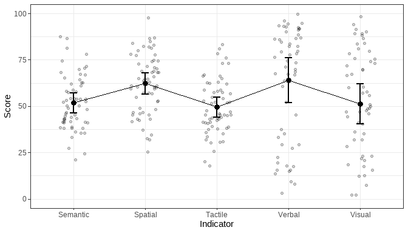

**Figure 1**. Plot of the 5 indicator variables.

```r
superb( DV ~ Indicator, data = dta,
        plotStyle   = "pointlinejitter",
        adjustments = list(purpose = "difference")
    ) + theme_bw() + ylim(0,100) + ylab("Score")
```

From these indicators, a clustering algorithm identified three distinct profiles. These profiles have different mean score on each indicator variables. As such, the plot can be done again, this time with different colors for each cluster of participants. We get.

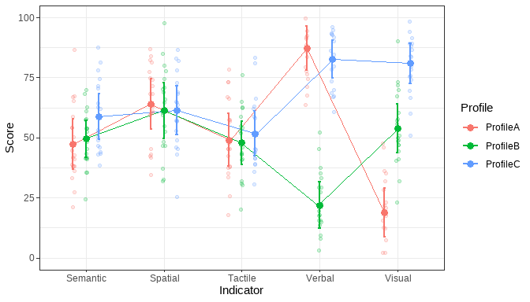

**Figure 2**. Plot of the 5 indicator variables and the three profiles.

```r
superb( DV ~ Indicator + Profile, data = dta,
        plotStyle   = "pointlinejitter",
        adjustments = list(purpose = "difference")
    ) + theme_bw() + ylim(0,100) + ylab("Score")
```

As see, the last indicator shows a wide diversity of scores well captured by the profile in which the participants belong.

## Turning the plot into a radar plot

To change the plot into a polar plot, simply change the layout. Changing from `"pointlinejitter"` to `"circularpointlinejitter"` does the trick:

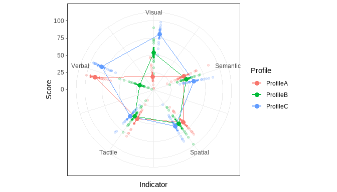

**Figure 3**. Plot of the 5 indicator variables and the three profiles in polar coordinate.

```r
superb( DV ~ Indicator + Profile, data = dta,
        plotStyle = "circularpointlinejitter"         ## only change!
    ) + theme_bw() + ylim(0,100) + ylab("Score")
```

We can undo the polar coordinate by forcing a cartesian coordinate system with:

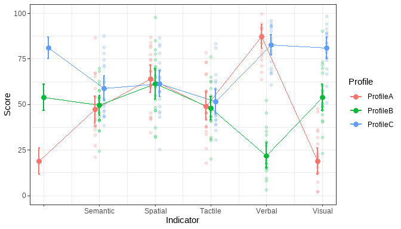

**Figure 4**. Plot of the 5 indicator variables and the three profiles back in cartesian coordinate.

```r
superb( DV ~ Indicator + Profile, data = dta,
        plotStyle = "circularpointlinejitter"
    ) + theme_bw() + ylim(0,100) + ylab("Score") +
    coord_cartesian()                                  ## only change!
```

It helps to see the one critical change: for the loop to close onto itself, an additional set of points are added at 0. It only reproduces the last points (here at Visual). When the plot is folded into a radial system, the first and last points superimpose.

## Interpreting the plot

The plot (either radar or cartesian) allow us to see that on three indicator variables, Semantic, Spatial, and Tactile, the three clusters of participants do not differ much. On the Verbal variable, the second profile *ProfileB* is differing from the other two profiles. Lastly, on the Visual variable, the three profiles have significantly different scores on average.

## Customizing the plot

All the plots produced by `superb()` are ggplot objects and so it is possible to add additional graphic directives to alter its look or to add additional geom.

In this code, we inject arguments into the `geom_line()` layer with `lineParams`. Here, we increase the line thickness. We also make the lines thicker but partially transparant by injecting `linewidth` and `alpha` in the `geom_line()` using `lineParams`. Finally, we also change the color palette. We can also remove the border around the plot, font size, etc.

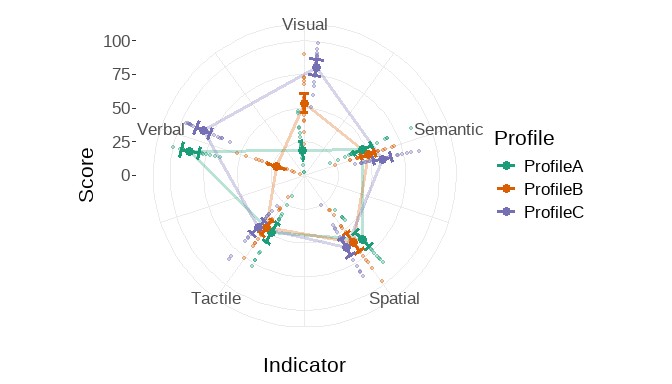

**Figure 5**. Plot with some customization

```r
library(RColorBrewer)
superb( DV ~ Indicator + Profile, data = dta,
        plotStyle      = "circularpointlinejitter",
        lineParams     = list(linewidth=1.2, alpha = 0.3 ),
        errorbarParams = list(width=0.3,linewidth=1.2 ),
        jitterParams   = list(size=1,alpha=0.33 ),
    ) + theme_bw() + ylim(0,100) + ylab("Score") +
    theme(panel.border = element_blank(), text = element_text(size = 16) ) +
    scale_color_brewer(palette="Dark2")
```

## Difference adjustments

In the present example, the reader is very likely to perform comparisons between curves so that the difference adjustment is needed. Simply add `purpose = "difference"` in the `adjustments` list. You will see that the error bars are now a bit longer to allow between-variable comparisons.

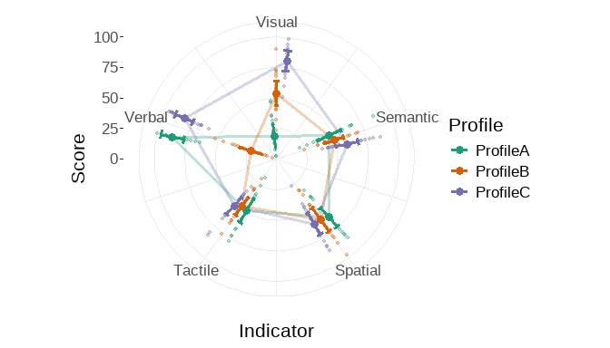

**Figure 6**. Plot with some difference adjustment

```r
superb( DV ~ Indicator + Profile, data = dta,
        adjustments    = list(purpose = "difference"), ## new addition
        plotStyle      = "circularpointlinejitter",
        lineParams     = list(linewidth=1.2, alpha = 0.3 ),
        errorbarParams = list(width=0.2,linewidth=1.2 ),
        jitterParams   = list(size=1,alpha=0.33 ),
    ) + theme_bw() + ylim(0,100) + ylab("Score") +
    theme(panel.border = element_blank(), text = element_text(size = 16) ) +
    scale_color_brewer(palette="Dark2")
```

If for any reason, you need to change `scale_x_continuous()`, you need to preserve a few arguments manually, they are

```r
    scale_x_continuous(
            oob = scales::oob_keep,
            limits =   c(0, 0.00001+NUMBER_OF_CATEGORIES ),
            n.breaks = NUMBER_OF_CATEGORIES +1
        )
```

where here `NUMBER_OF_CATEGORIES` would be 5 in this example.

You can also rotate the plot or make it turn in the opposite direction with the `radarParams` list, e.g.,

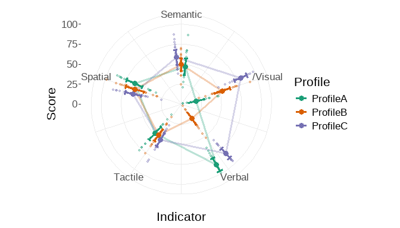

**Figure 7**. Plot turning counterclockwise

```r
superb( DV ~ Indicator + Profile, data = dta,
        adjustments    = list(purpose = "difference"), ## new addition
        plotStyle      = "circularpointlinejitter",
        lineParams     = list(linewidth=1.2, alpha = 0.3 ),
        errorbarParams = list(width=0.2,linewidth=1.2 ),
        jitterParams   = list(size=1,alpha=0.33 ),
        radarParams    = list( direction = -1, start = 2*pi *4/5)
    ) + theme_bw() + ylim(0,100) + ylab("Score") +
    theme(panel.border = element_blank(), text = element_text(size = 16) ) +
    scale_color_brewer(palette="Dark2")
```

## Generating random data

The data used herein have been randomly generated with the `GRD()` (Generate Random Data) function included in `superb` (quite useful to test plot functions!).

Here, we generated data for three profiles and 5 indicators. The effect are from an interaction between the two factors, adding or removing points on average on the grand mean which is 50. s

```r
dta <- GRD(
    SubjectsPerGroup = 20,
    BSFactors        = c("Profile(ProfileA,ProfileB,ProfileC)","Indicator(Visual,Spatial,Verbal,Tactile,Semantic)"),
    Population       = list(mean=50,stddev=15),
    Effects          = list("Profile*Indicator" = custom(-30,0,30,10,10,10,30,-20,30,0,0,0,0,0,0)))
```

## In summary

Radar plots are compact ways to represent means for a few groups when the order of the categories on the x-axis are arbitrary. `superb` and its layouts `"circular*"` automatize the steps to create a circular dataset and show it on a radial coordinate system.

# References

Delem, M., Turkben, S., Cousineau, D., Cavalli, E., & Plancher, G. (2024). Uncovering spatial and verbal cognitive profiles in aphantasia through unsupervised clustering. *Submitted*, *submitted*, 1–63.